# scRNA-seq and ST school July 4

Cameron Williams

2024-07-04

The point of this meeting will be to understand how you can use R to manipulate and visualise data.

This will follow on from last week’s meeting in which we discussed R data types. In particular, we will focus on the data.frame type, and to an extent the matrix type.

While base R (i.e. R sans packages) has functionality for viewing and manipulating data types, we will use a package, dplyr, which provides succinct functions for working with dataframes as well as some other features which we’ll discuss below.

We’ll begin by loading tidyverse and manipulating an R built-in dataset, mtcars, as an example.

```r
library(tidyverse)
## built in dataset
mtcars
```

```
##                      mpg cyl  disp  hp drat    wt  qsec vs am gear carb
## Mazda RX4           21.0   6 160.0 110 3.90 2.620 16.46  0  1    4    4
## Mazda RX4 Wag       21.0   6 160.0 110 3.90 2.875 17.02  0  1    4    4
## Datsun 710          22.8   4 108.0  93 3.85 2.320 18.61  1  1    4    1
## Hornet 4 Drive      21.4   6 258.0 110 3.08 3.215 19.44  1  0    3    1
## Hornet Sportabout   18.7   8 360.0 175 3.15 3.440 17.02  0  0    3    2
## Valiant             18.1   6 225.0 105 2.76 3.460 20.22  1  0    3    1
## Duster 360          14.3   8 360.0 245 3.21 3.570 15.84  0  0    3    4
## Merc 240D           24.4   4 146.7  62 3.69 3.190 20.00  1  0    4    2
## Merc 230            22.8   4 140.8  95 3.92 3.150 22.90  1  0    4    2
## Merc 280            19.2   6 167.6 123 3.92 3.440 18.30  1  0    4    4
## Merc 280C           17.8   6 167.6 123 3.92 3.440 18.90  1  0    4    4
## Merc 450SE          16.4   8 275.8 180 3.07 4.070 17.40  0  0    3    3
## Merc 450SL          17.3   8 275.8 180 3.07 3.730 17.60  0  0    3    3
## Merc 450SLC         15.2   8 275.8 180 3.07 3.780 18.00  0  0    3    3
## Cadillac Fleetwood  10.4   8 472.0 205 2.93 5.250 17.98  0  0    3    4
## Lincoln Continental 10.4   8 460.0 215 3.00 5.424 17.82  0  0    3    4
## Chrysler Imperial   14.7   8 440.0 230 3.23 5.345 17.42  0  0    3    4
## Fiat 128            32.4   4  78.7  66 4.08 2.200 19.47  1  1    4    1
## Honda Civic         30.4   4  75.7  52 4.93 1.615 18.52  1  1    4    2
## Toyota Corolla      33.9   4  71.1  65 4.22 1.835 19.90  1  1    4    1
## Toyota Corona       21.5   4 120.1  97 3.70 2.465 20.01  1  0    3    1
## Dodge Challenger    15.5   8 318.0 150 2.76 3.520 16.87  0  0    3    2
## AMC Javelin         15.2   8 304.0 150 3.15 3.435 17.30  0  0    3    2
## Camaro Z28          13.3   8 350.0 245 3.73 3.840 15.41  0  0    3    4
## Pontiac Firebird    19.2   8 400.0 175 3.08 3.845 17.05  0  0    3    2
## Fiat X1-9           27.3   4  79.0  66 4.08 1.935 18.90  1  1    4    1
## Porsche 914-2       26.0   4 120.3  91 4.43 2.140 16.70  0  1    5    2
## Lotus Europa        30.4   4  95.1 113 3.77 1.513 16.90  1  1    5    2
## Ford Pantera L      15.8   8 351.0 264 4.22 3.170 14.50  0  1    5    4
## Ferrari Dino        19.7   6 145.0 175 3.62 2.770 15.50  0  1    5    6
## Maserati Bora       15.0   8 301.0 335 3.54 3.570 14.60  0  1    5    8
## Volvo 142E          21.4   4 121.0 109 4.11 2.780 18.60  1  1    4    2
```

And a quick refresher on how to access data inside a dataframe via positional indices.

```r
mtcars[1,]
```

```
##           mpg cyl disp  hp drat   wt  qsec vs am gear carb
## Mazda RX4  21   6  160 110  3.9 2.62 16.46  0  1    4    4
```

```r
mtcars[,1]
```

```
##  [1] 21.0 21.0 22.8 21.4 18.7 18.1 14.3 24.4 22.8 19.2 17.8 16.4 17.3 15.2 10.4
## [16] 10.4 14.7 32.4 30.4 33.9 21.5 15.5 15.2 13.3 19.2 27.3 26.0 30.4 15.8 19.7
## [31] 15.0 21.4
```

```r
mtcars[1,1]
```

```
## [1] 21
```

```r
mtcars$cyl
```

```
##  [1] 6 6 4 6 8 6 8 4 4 6 6 8 8 8 8 8 8 4 4 4 4 8 8 8 8 4 4 4 8 6 8 4
```

Now we’ll use dplyr to manipulate the data. dplyr is easy to use because it’s succinct, requiring little code compared to more hands-on base R methods. Let’s filter the data based on miles per gallon.

```r
mtcars$mpg %>% summary() ## get median, IQR, etc
```

```
##    Min. 1st Qu.  Median    Mean 3rd Qu.    Max.
##   10.40   15.43   19.20   20.09   22.80   33.90
```

```r
mtcars %>% filter(mpg >= 22.80) ## get only entries in the top quartile
```

```
##                 mpg cyl  disp  hp drat    wt  qsec vs am gear carb
## Datsun 710     22.8   4 108.0  93 3.85 2.320 18.61  1  1    4    1
## Merc 240D      24.4   4 146.7  62 3.69 3.190 20.00  1  0    4    2
## Merc 230       22.8   4 140.8  95 3.92 3.150 22.90  1  0    4    2
## Fiat 128       32.4   4  78.7  66 4.08 2.200 19.47  1  1    4    1
## Honda Civic    30.4   4  75.7  52 4.93 1.615 18.52  1  1    4    2
## Toyota Corolla 33.9   4  71.1  65 4.22 1.835 19.90  1  1    4    1
## Fiat X1-9      27.3   4  79.0  66 4.08 1.935 18.90  1  1    4    1
## Porsche 914-2  26.0   4 120.3  91 4.43 2.140 16.70  0  1    5    2
## Lotus Europa   30.4   4  95.1 113 3.77 1.513 16.90  1  1    5    2
```

You probably haven’t seen one of the operators used above, %>%. This is the pipe symbol. Typically, R functions are written somewhat like an intransient sentence, with a function/verb and subject/dataset. The pipe symbol allows you to pre-specify the dataset and then “pipe” it to downstream functions without having to write them on sequential lines. For example, we can pipe the output from our filter function above to another filter function.

```r
mtcars %>% filter(mpg >= 22.80) %>% filter(mpg < 30)
```

```
##                mpg cyl  disp hp drat    wt  qsec vs am gear carb
## Datsun 710    22.8   4 108.0 93 3.85 2.320 18.61  1  1    4    1
## Merc 240D     24.4   4 146.7 62 3.69 3.190 20.00  1  0    4    2
## Merc 230      22.8   4 140.8 95 3.92 3.150 22.90  1  0    4    2
## Fiat X1-9     27.3   4  79.0 66 4.08 1.935 18.90  1  1    4    1
## Porsche 914-2 26.0   4 120.3 91 4.43 2.140 16.70  0  1    5    2
```

You can also assign the output.

```r
mtcars_filtered <- mtcars %>% filter(mpg >= 22.80) %>% filter(mpg < 30)
mtcars_filtered
```

```
##                mpg cyl  disp hp drat    wt  qsec vs am gear carb
## Datsun 710    22.8   4 108.0 93 3.85 2.320 18.61  1  1    4    1
## Merc 240D     24.4   4 146.7 62 3.69 3.190 20.00  1  0    4    2
## Merc 230      22.8   4 140.8 95 3.92 3.150 22.90  1  0    4    2
## Fiat X1-9     27.3   4  79.0 66 4.08 1.935 18.90  1  1    4    1
## Porsche 914-2 26.0   4 120.3 91 4.43 2.140 16.70  0  1    5    2
```

You can also use dplyr to create new columns (“mutate” the dataframe) or remove existing columns, as shown below with a logical expression to determine whether entries in the mpg column are above or below the median.

```r
mtcars %>% mutate(mpg_above_median = mpg > median(mpg)) %>% select(mpg_above_median, mpg) ## retain only mpg and mpg_above_median columns
```

```
##                     mpg_above_median  mpg
## Mazda RX4                       TRUE 21.0
## Mazda RX4 Wag                   TRUE 21.0
## Datsun 710                      TRUE 22.8
## Hornet 4 Drive                  TRUE 21.4
## Hornet Sportabout              FALSE 18.7
## Valiant                        FALSE 18.1
## Duster 360                     FALSE 14.3
## Merc 240D                       TRUE 24.4
## Merc 230                        TRUE 22.8
## Merc 280                       FALSE 19.2
## Merc 280C                      FALSE 17.8
## Merc 450SE                     FALSE 16.4
## Merc 450SL                     FALSE 17.3
## Merc 450SLC                    FALSE 15.2
## Cadillac Fleetwood             FALSE 10.4
## Lincoln Continental            FALSE 10.4
## Chrysler Imperial              FALSE 14.7
## Fiat 128                        TRUE 32.4
## Honda Civic                     TRUE 30.4
## Toyota Corolla                  TRUE 33.9
## Toyota Corona                   TRUE 21.5
## Dodge Challenger               FALSE 15.5
## AMC Javelin                    FALSE 15.2
## Camaro Z28                     FALSE 13.3
## Pontiac Firebird               FALSE 19.2
## Fiat X1-9                       TRUE 27.3
## Porsche 914-2                   TRUE 26.0
## Lotus Europa                    TRUE 30.4
## Ford Pantera L                 FALSE 15.8
## Ferrari Dino                    TRUE 19.7
## Maserati Bora                  FALSE 15.0
## Volvo 142E                      TRUE 21.4
```

While this is barely scratching the surface of dplyr’s applications, it can also be used to create fast summaries of data. For example, we can summarise the median mpg of cars in the dataset grouped by the number of cylinders.

```r
mtcars %>%
  group_by(cyl) %>% ## group the data
  summarise(median(mpg)) ## get the median mpg per group
```

```
## # A tibble: 3 × 2
##     cyl `median(mpg)`
##   <dbl>         <dbl>
## 1     4          26
## 2     6          19.7
## 3     8          15.2
```

Being a popular data manipulation package, there are plenty of guides out there on how to use dplyr but I will direct you to this cheatsheet:

https://www.rstudio.com/wp-content/uploads/2015/02/data-wrangling-cheatsheet.pdf

Most of the time, we publish our data in plots rather than as raw data, so it’s helpful to understand how we make those plots. Most of our R plotting is done with another tidyverse package, ggplot2. To use this package to create a simple plot, you only need to specify three things: an x variable, a y variable, and a “geom”, basically a plot geometry such as a scatter plot, line plot, histogram, etc. The data itself is passed to ggplot2 through the “ggplot” function and the geom is added to the plot with an operator +. I’ll give you a demo with the cars dataset.

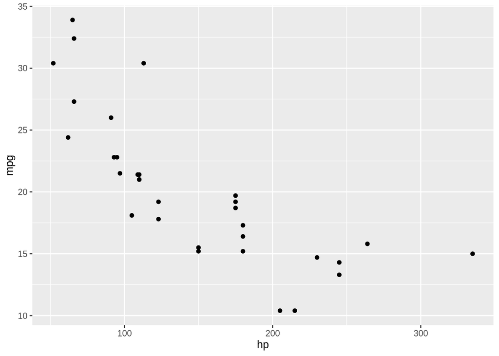

```r
ggplot(
  data = mtcars, ## what dataset the variables are in
  mapping = aes(x = hp, y = mpg) ## what variables to plot as x and y
) + geom_point() ## what geometry to use
```

You can stack multiple geometries into the same plot.

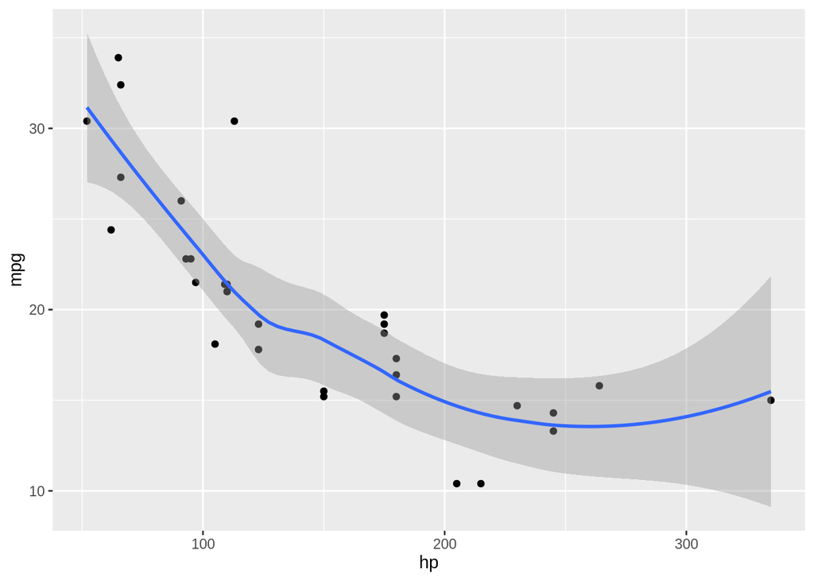

```r
ggplot(
  data = mtcars,
  mapping = aes(x = hp, y = mpg)
) + geom_point() + geom_smooth() ## do both a scatter plot and a trend line
```

These are the core functions of ggplot. However, you can add additional information, such as categories by which ggplot can colour the data.

Now is also a good time to mention a data type we haven’t discussed, the factor class. Factors represent ordinal or categorical data. Here we will categorise the data according to the number of cylinders, which requires us to convert it from the numeric class to the factor class as shown below.

```r
class(mtcars$cyl)
```

```
## [1] "numeric"
```

```r
class(
  mtcars$cyl %>% as.factor()
  )
```

```
## [1] "factor"
```

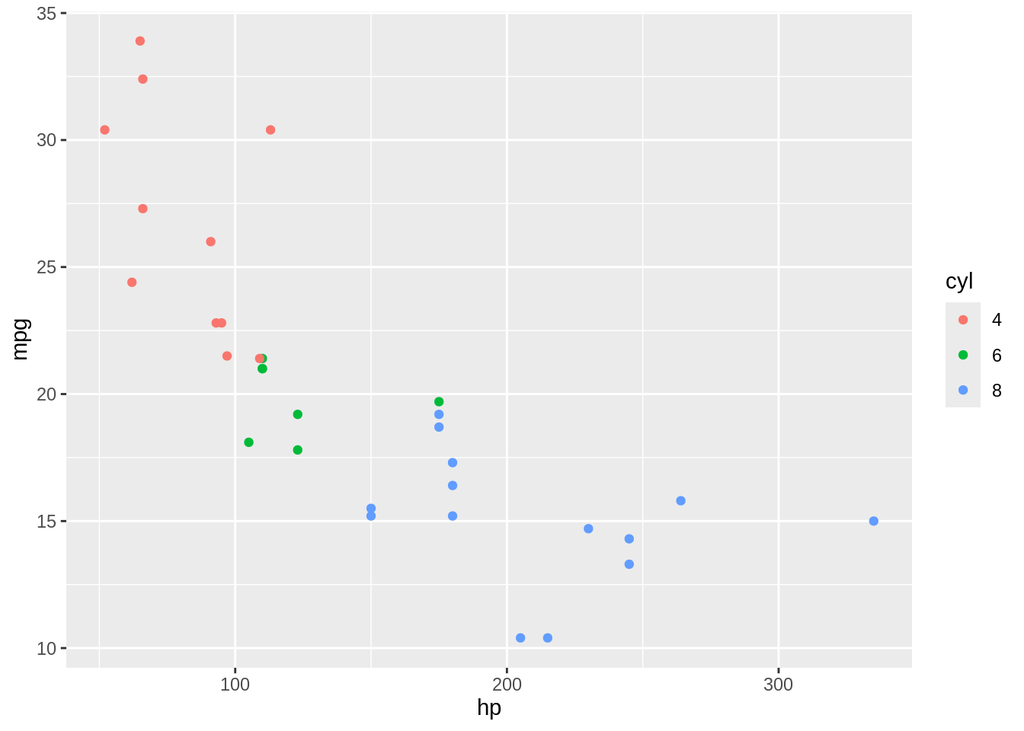

```r
ggplot(
  data = mtcars %>% mutate(cyl = as.factor(cyl)),
  mapping = aes(x = hp, y = mpg, colour=cyl)
) + geom_point()
```

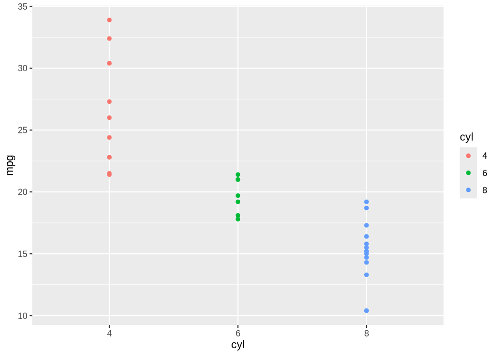

```r
ggplot(
  data = mtcars %>% mutate(cyl = as.factor(cyl)),
  mapping = aes(x = cyl, y = mpg, colour=cyl)
) + geom_point()
```

Again, we can stack geometries on top of each other. Let’s use a violin plot geometry.

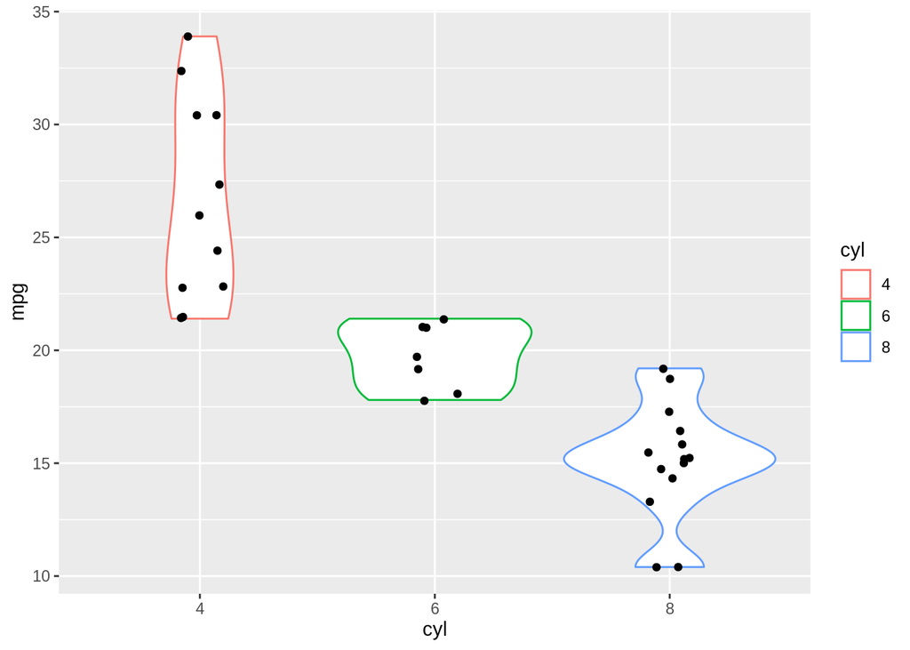

```r
ggplot(
  data = mtcars %>% mutate(cyl = as.factor(cyl)),
  mapping = aes(x = cyl, y = mpg, colour=cyl)
) + geom_violin() + geom_jitter(colour = 'black', width = 0.1) ## add some horizontal jitter for legibility
```

Finally, we can change the look of the plot. Each element including the background, text, axes, axis intervals, legend, title, etc. can be altered but for ease of use ggplot2 includes a number of pre-designed “themes” that will edit all of these at once in a single function.

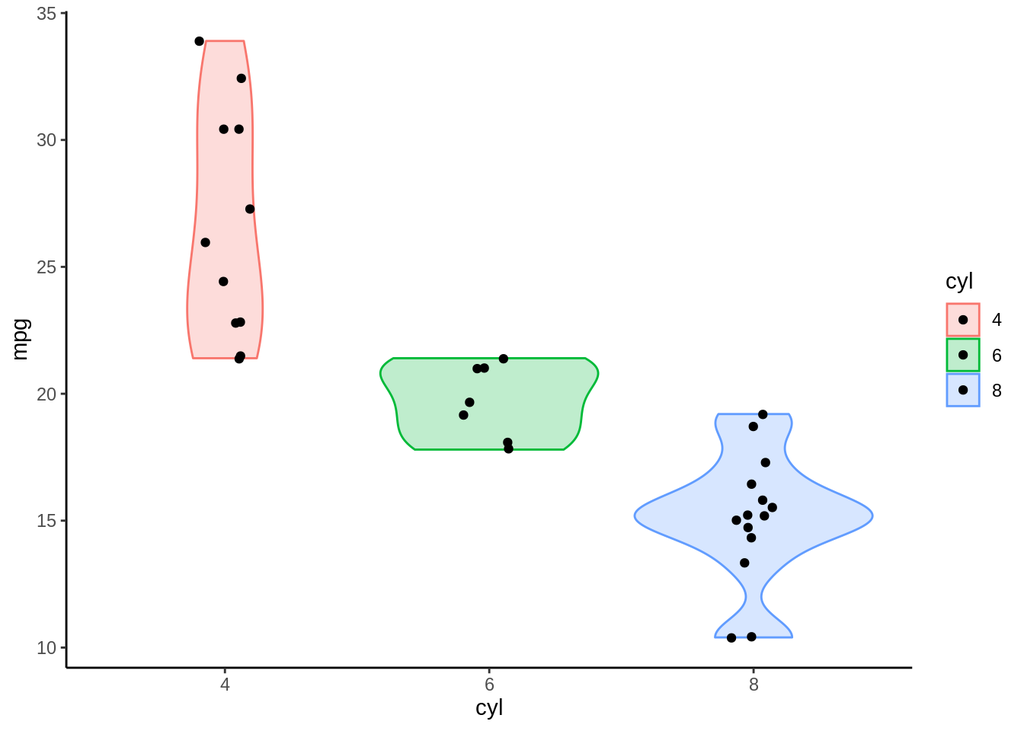

```r
ggplot(
  data = mtcars %>% mutate(cyl = as.factor(cyl)),
  mapping = aes(x = cyl, y = mpg, colour=cyl, fill=cyl)
) + geom_violin(alpha=0.25) + geom_jitter(colour = 'black', width = 0.1) +
  theme_classic()
```

To finish things off, let’s plot some Seurat data. Seurat has its own plotting functions but they run on ggplot2 and we can add aesthetic features like we did with the plots above. For example:

```r
library(Seurat)
```

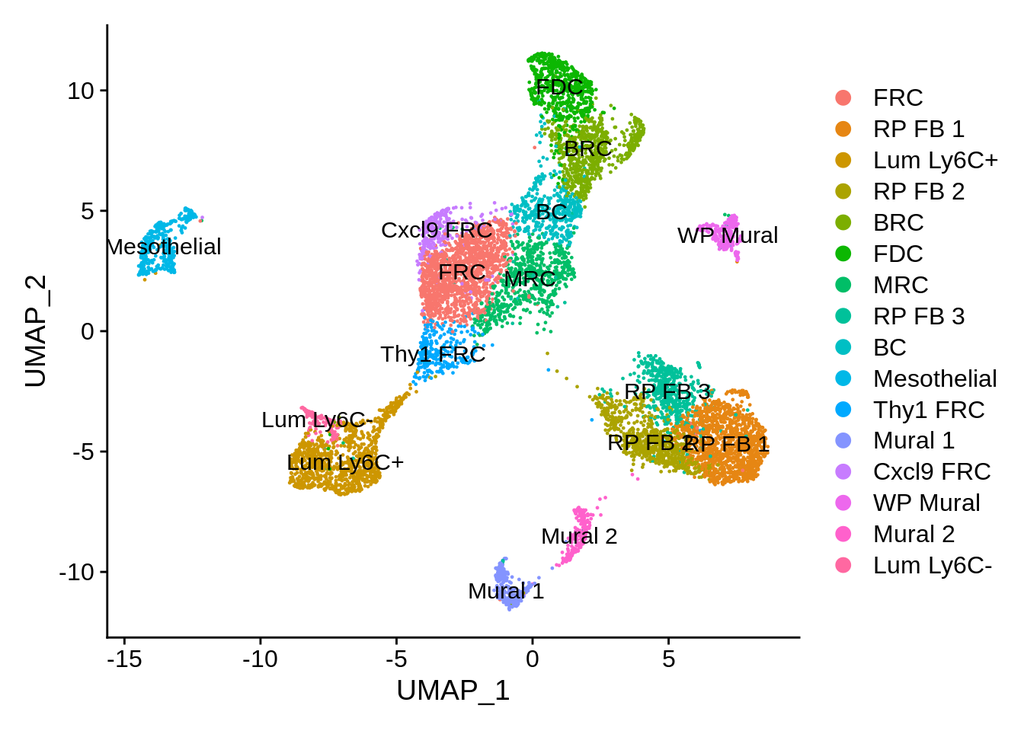

```r
## load stroma
msc <- readRDS("/data/gpfs/projects/punim1236/spleen_st/Seurat_objects/Mueller_MSCs_old.rds")

## plot
DimPlot(msc, label=T)
```

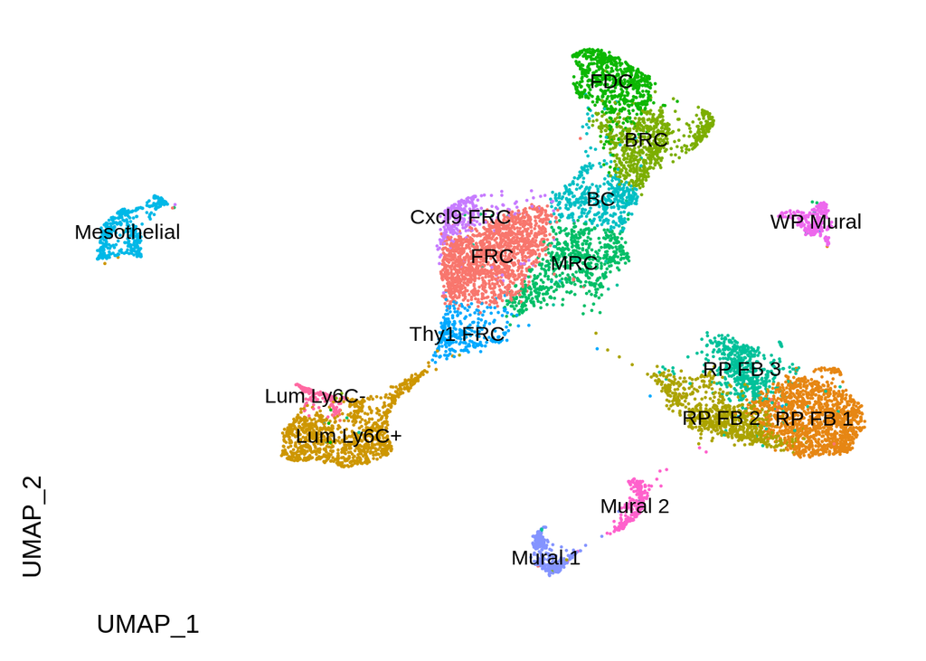

```r
## plot without bulky legend and axis text using the "theme" function
DimPlot(msc, label=T) + theme(
  legend.position = 'none',
  axis.text = element_blank(),
  axis.ticks = element_blank(),
  axis.line = element_blank(),
  axis.title.x = element_text(hjust = 0.05),
  axis.title.y = element_text(hjust = 0.05)
)
```

We can also plot it with different aspect ratios, which helps with figure design.

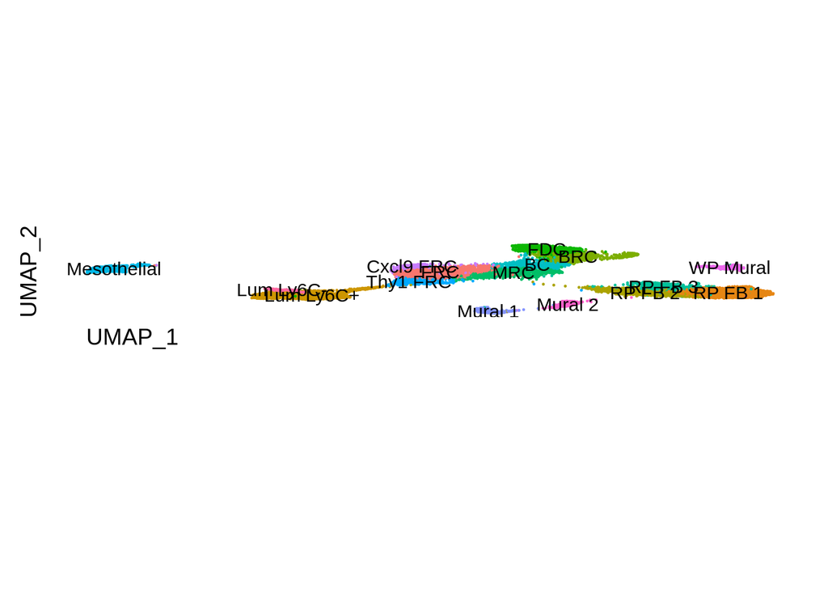

```r
## plot on a weird aspect ratio
DimPlot(msc, label=T) + theme(
  legend.position = 'none',
  axis.text = element_blank(),
  axis.ticks = element_blank(),
  axis.line = element_blank(),
  axis.title.x = element_text(hjust = 0.05),
  axis.title.y = element_text(hjust = 0.05)
) + theme(
  aspect.ratio = 0.1
)
```

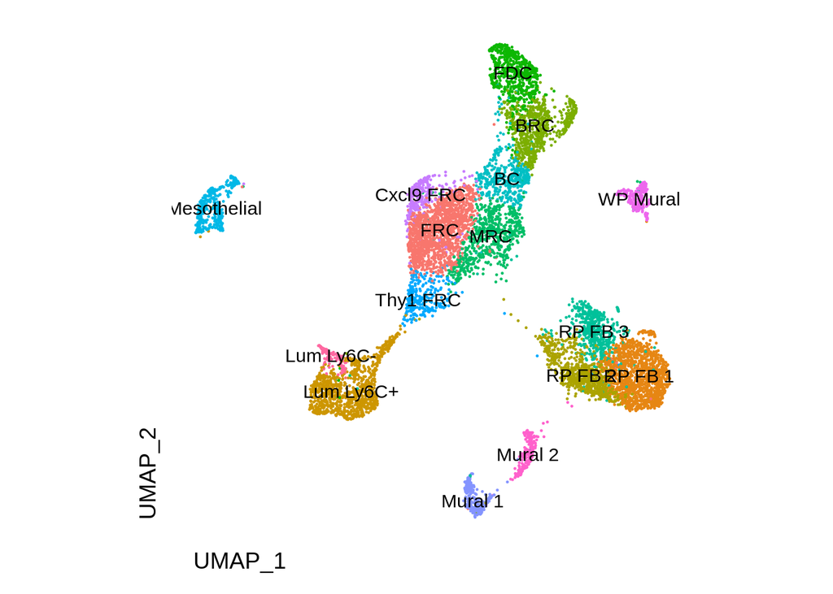

```r
## plot with relative axis lengths
DimPlot(msc, label=T) + theme(
  legend.position = 'none',
  axis.text = element_blank(),
  axis.ticks = element_blank(),
  axis.line = element_blank(),
  axis.title.x = element_text(hjust = 0.05),
  axis.title.y = element_text(hjust = 0.05)
) + coord_fixed()
```

And we can revisit our dplyr skills to get some QC information on these cells.

```r
## get median UMIs per cell type
msc@meta.data %>% mutate(celltype = msc@active.ident) %>% group_by(celltype) %>% summarise(median(nCount_RNA))
```

```
## # A tibble: 16 × 2
##    celltype    `median(nCount_RNA)`
##    <fct>                      <dbl>
##  1 FRC                        5937
##  2 RP FB 1                    4212.
##  3 Lum Ly6C+                  6242
##  4 RP FB 2                    3660.
##  5 BRC                        6681
##  6 FDC                        5694.
##  7 MRC                        5888
##  8 RP FB 3                    3826.
##  9 BC                         8315
## 10 Mesothelial                6055
## 11 Thy1 FRC                   5216
## 12 Mural 1                    6171
## 13 Cxcl9 FRC                  6680
## 14 WP Mural                   3309
## 15 Mural 2                    4438
## 16 Lum Ly6C-                  6190.
```

```r
## get median genes detected per cell type
msc@meta.data %>% mutate(celltype = msc@active.ident) %>% group_by(celltype) %>% summarise(median(nFeature_RNA))
```

```
## # A tibble: 16 × 2
##    celltype    `median(nFeature_RNA)`
##    <fct>                        <dbl>
##  1 FRC                          2507
##  2 RP FB 1                      2237
##  3 Lum Ly6C+                    2601
##  4 RP FB 2                      2004.
##  5 BRC                          2819
##  6 FDC                          2660.
##  7 MRC                          2534
##  8 RP FB 3                      2159
##  9 BC                           3134
## 10 Mesothelial                  2616.
## 11 Thy1 FRC                     2393
## 12 Mural 1                      2845
## 13 Cxcl9 FRC                    2689
## 14 WP Mural                     1844
## 15 Mural 2                      2207
## 16 Lum Ly6C-                    2694.
```